# 重賞レース予測レポート【毎時自動更新中】

作成日時: 2026/08/02 14:05:35

☞ [マニュアル(pdf)](https://ryutoro-galois.github.io/keiba-predictor/manual/manual.pdf)

☞ 過去6年の同一レース結果: [2025年](https://ryutoro-galois.github.io/keiba-predictor/report/PredResult_2025y_raceDate_20250803_20250803.html), [2024年](https://ryutoro-galois.github.io/keiba-predictor/report/PredResult_2024y_raceDate_20240727_20240728.html), [2023年](https://ryutoro-galois.github.io/keiba-predictor/report/PredResult_2023y_raceDate_20230729_20230730.html), [2022年](https://ryutoro-galois.github.io/keiba-predictor/report/PredResult_2022y_raceDate_20220731_20220731.html), [2021年](https://ryutoro-galois.github.io/keiba-predictor/report/PredResult_2021y_raceDate_20210731_20210801.html), [2020年](https://ryutoro-galois.github.io/keiba-predictor/report/PredResult_2020y_raceDate_20200802_20200802.html)

☞ 過去4週間の別レース結果: [1週前(7/26)](https://ryutoro-galois.github.io/keiba-predictor/report/PredResult_2026y_raceDate_20260726_20260726.html), [2週前(7/19)](https://ryutoro-galois.github.io/keiba-predictor/report/PredResult_2026y_raceDate_20260719_20260719.html), [3週前(7/12)](https://ryutoro-galois.github.io/keiba-predictor/report/PredResult_2026y_raceDate_20260712_20260712.html), [4週前(7/5)](https://ryutoro-galois.github.io/keiba-predictor/report/PredResult_2026y_raceDate_20260705_20260705.html)

☞ netkeiba: [アイビスサマーD(GⅢ)](https://race.netkeiba.com/race/shutuba.html?race_id=202604020407&rf=race_list), [クイーンステークス(GⅢ)](https://race.netkeiba.com/race/shutuba.html?race_id=202601010411&rf=race_list)

## 0. 推し馬予測 (AI予測)

### 【クイーンステークス(GⅢ) 2026/08/02(日)】

- 本命(◎): 1-3着内確率(勝負強さ)が1位の馬
- 対抗(◯): 1-3着内確率が2-N位(20%程度以上)の中で予測タイムが最も速い馬
- 3番手(▲): 1-3着内確率が2-N位(20%程度以上)のでダークホース確率が最も高い馬
- 穴: ダークホース確率が上位1-M位(40%程度以上)の中で1-3着内確率が最も高い馬

| 推し馬 | 枠番 | 馬番 | 人気 | オッズ | 馬名 | 騎手 | 調教師 | 予測タイム(sec) | 1_順位 | 1-3着内確率(%) | 2_順位 | ﾀﾞｰｸﾎｰｽ確率(%) | 3_順位 |
| --- | --- | --- | --- | --- | --- | --- | --- | --- | --- | --- | --- | --- | --- |
| 本命(◎) | 5 | 7 | 2 | 3.5 | ココナッツブラウン | 北村友一 | 上村洋行 | 112.4 | 10 | 33.3 | 1 | 0.4 | 14 |
| 対抗(◯) | 2 | 2 | 4 | 12.9 | ケリフレッドアスク | 横山武史 | 藤原英昭 | 109.1 | 4 | 24.1 | 2 | 1.3 | 11 |
| 3番手(▲) | 7 | 12 | 7 | 14.8 | ボンドガール | 佐々木大輔 | 手塚貴久 | 110.7 | 9 | 22.4 | 3 | 1.5 | 8 |
| 穴 | 4 | 6 | 14 | 97.7 | クリノメイ | 富田暁 | 須貝尚介 | 108.5 | 2 | 9.8 | 8 | 44.3 | 1 |

### 【アイビスサマーD(GⅢ) 2026/08/02(日)】

- 本命(◎): 1-3着内確率(勝負強さ)が1位の馬
- 対抗(◯): 1-3着内確率が2-N位(20%程度以上)の中で予測タイムが最も速い馬
- 3番手(▲): 1-3着内確率が2-N位(20%程度以上)のでダークホース確率が最も高い馬
- 穴: ダークホース確率が上位1-M位(40%程度以上)の中で1-3着内確率が最も高い馬

| 推し馬 | 枠番 | 馬番 | 人気 | オッズ | 馬名 | 騎手 | 調教師 | 予測タイム(sec) | 1_順位 | 1-3着内確率(%) | 2_順位 | ﾀﾞｰｸﾎｰｽ確率(%) | 3_順位 |
| --- | --- | --- | --- | --- | --- | --- | --- | --- | --- | --- | --- | --- | --- |
| 本命(◎) | 8 | 16 | 2 | 4.6 | アメリカンステージ | 戸崎圭太 | 矢作芳人 | 60.9 | 16 | 41.6 | 1 | 0.4 | 15 |
| 対抗(◯) | 8 | 17 | 4 | 8.3 | ビッグシーザー | 荻野極 | 杉山晴紀 | 53.8 | 2 | 30.5 | 2 | 1.1 | 12 |
| 3番手(▲) | 1 | 1 | 5 | 15.0 | ウイングレイテスト | 松岡正海 | 畠山吉宏 | 62.9 | 17 | 25.8 | 3 | 1.1 | 11 |
| 穴 | 7 | 14 | 17 | 147.8 | ブーケファロス | 石橋脩 | 清水英克 | 59.7 | 10 | 4.0 | 11 | 40.3 | 2 |

## 1. 予測チャート (タイム/勝負強さ)

### 【クイーンステークス(GⅢ)】

2026/08/02(日), 01_札幌, 芝右1800m

[interactive chart not shown]

### 【アイビスサマーD(GⅢ)】

2026/08/02(日), 04_新潟, 芝直線1000m

[interactive chart not shown]

## 2. オッズモニタリング (毎時)

### 【クイーンステークス】

[interactive chart not shown]

### 【アイビスサマーD】

[interactive chart not shown]

## 3. 出馬表

### 【クイーンステークス 2026/08/02(日) 】

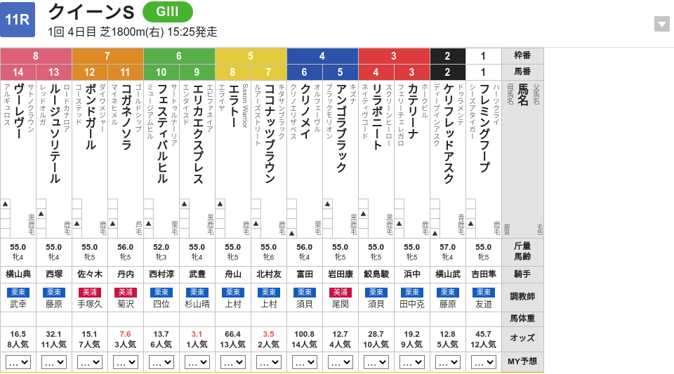

### 【アイビスサマーD 2026/08/02(日) 】

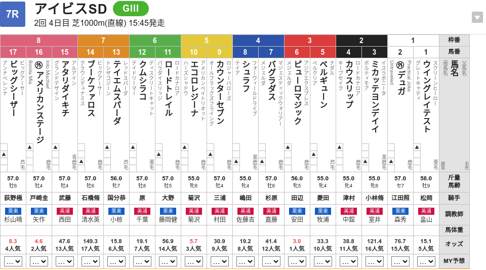

## 4. 単勝予測結果

### 【クイーンステークス(GⅢ) 2026/08/02(日)】

| 枠番 | 馬番 | 人気 | オッズ | 馬名 | 騎手 | 調教師 | 予測タイム(sec) | 1_順位 | 1-3着内確率(%) | 2_順位 | ﾀﾞｰｸﾎｰｽ確率(%) | 3_順位 |
| --- | --- | --- | --- | --- | --- | --- | --- | --- | --- | --- | --- | --- |
| 1 | 1 | 12 | 44.9 | フレミングフープ | 吉田隼人 | 友道康夫 | 114.5 | 11.0 | 3.7 | 12 | 11.8 | 6 |
| 2 | 2 | 4 | 12.9 | ケリフレッドアスク | 横山武史 | 藤原英昭 | 109.1 | 4.0 | 24.1 | 2 | 1.3 | 11 |
| 3 | 3 | 9 | 19.3 | カテリーナ | 浜中俊 | 田中克典 | 116.9 | 12.0 | 3.4 | 13 | 10.3 | 7 |
| 3 | 4 | 10 | 28.1 | リラボニート | 鮫島克駿 | 須貝尚介 | 109.2 | 5.5 | 9.8 | 7 | 39.3 | 3 |
| 4 | 5 | 6 | 13.3 | アンゴラブラック | 岩田康誠 | 尾関知人 | 109.6 | 7.0 | 21.6 | 4 | 1.3 | 10 |
| 4 | 6 | 14 | 97.7 | クリノメイ | 富田暁 | 須貝尚介 | 108.5 | 2.0 | 9.8 | 8 | 44.3 | 1 |
| 5 | 7 | 2 | 3.5 | ココナッツブラウン | 北村友一 | 上村洋行 | 112.4 | 10.0 | 33.3 | 1 | 0.4 | 14 |
| 5 | 8 | 13 | 65.1 | エラトー | 舟山瑠泉 | 上村洋行 | 119.8 | 14.0 | 3.0 | 14 | 39.6 | 2 |
| 6 | 9 | 1 | 3.1 | エリカエクスプレス | 武豊 | 杉山晴紀 | 105.7 | 1.0 | 19.0 | 6 | 0.4 | 13 |
| 6 | 10 | 5 | 13.1 | フェスティバルヒル | 西村淳也 | 四位洋文 | 110.1 | 8.0 | 20.1 | 5 | 1.4 | 9 |

[output cut: 4 more lines]

### 【アイビスサマーD(GⅢ) 2026/08/02(日)】

| 枠番 | 馬番 | 人気 | オッズ | 馬名 | 騎手 | 調教師 | 予測タイム(sec) | 1_順位 | 1-3着内確率(%) | 2_順位 | ﾀﾞｰｸﾎｰｽ確率(%) | 3_順位 |
| --- | --- | --- | --- | --- | --- | --- | --- | --- | --- | --- | --- | --- |
| 1 | 1 | 5 | 15.0 | ウイングレイテスト | 松岡正海 | 畠山吉宏 | 62.9 | 17 | 25.8 | 3 | 1.1 | 11 |
| 1 | 2 | 15 | 75.4 | デュガ | 江田照男 | 森秀行 | 58.4 | 6 | 5.2 | 9 | 11.6 | 7 |
| 2 | 3 | 16 | 120.3 | ミカッテヨンデイイ | 小林脩斗 | 室井潔 | 59.2 | 8 | 3.5 | 12 | 32.0 | 3 |
| 2 | 4 | 11 | 38.5 | カウスリップ | 津村明秀 | 中舘英二 | 60.3 | 13 | 3.5 | 13 | 27.9 | 4 |
| 3 | 5 | 10 | 32.7 | ベルギューン | 菱田裕二 | 牧浦充徳 | 59.7 | 11 | 3.4 | 14 | 12.6 | 6 |
| 3 | 6 | 1 | 3.0 | ピューロマジック | 田辺裕信 | 安田翔伍 | 53.8 | 2 | 6.6 | 8 | 0.3 | 17 |
| 4 | 7 | 12 | 41.3 | バグラダス | 杉原誠人 | 嘉藤貴行 | 60.8 | 15 | 2.0 | 17 | 44.5 | 1 |
| 4 | 8 | 8 | 19.0 | シュラフ | 嶋田純次 | 佐藤吉勝 | 53.8 | 2 | 16.4 | 5 | 1.3 | 10 |
| 5 | 9 | 9 | 31.1 | カウンターセブン | 三浦皇成 | 村田一誠 | 59.1 | 7 | 4.0 | 10 | 0.9 | 14 |
| 5 | 10 | 3 | 5.6 | エコロレジーナ | 菊沢一樹 | 菊沢隆徳 | 60.7 | 14 | 14.2 | 6 | 0.4 | 16 |

[output cut: 7 more lines]

## 5. 人気と着順の乖離率推移

### 【クイーンステークス_1990y_2019y】

[interactive chart not shown]

### 【アイビスサマーD_2001y_2019y】

[interactive chart not shown]

### 【クイーンステークス_1990y_2019y】

| No | 開催年 | 不整合率(%) | 頭数 | 人気別着順(1-3位) | 人気別着順(全体) |
| --- | --- | --- | --- | --- | --- |
| 30 | 2019 | 40.9 | 14頭 | 1-5-9 | 1\|5\|9\|4\|8\|3\|2\|7\|12\|10\|14\|13\|11\|6 |
| 29 | 2018 | 27.3 | 11頭 | 1-4-2 | 1\|4\|2\|7\|9\|8\|6\|10\|5\|3\|11 |
| 28 | 2017 | 36.9 | 13頭 | 2-6-8 | 2\|6\|8\|5\|10\|1\|3\|12\|7\|4\|13\|11\|9 |
| 27 | 2016 | 33.1 | 13頭 | 9-1-11 | 9\|1\|11\|8\|5\|6\|10\|2\|4\|3\|13\|7\|12 |
| 26 | 2015 | 47.3 | 10頭 | 7-1-4 | 7\|1\|4\|6\|5\|8\|3\|2\|9\|10 |
| 25 | 2014 | 25.6 | 14頭 | 2-6-1 | 2\|6\|1\|9\|3\|8\|4\|13\|5\|11\|7\|14\|10\|12 |
| 24 | 2013 | 21.0 | 8頭 | 1-8-3 | 1\|8\|3\|2\|4\|6\|7\|5 |
| 23 | 2012 | 31.2 | 14頭 | 1-10-4 | 1\|10\|4\|3\|2\|14\|8\|5\|13\|7\|9\|11\|12\|6 |
| 22 | 2011 | 29.3 | 14頭 | 1-10-3 | 1\|10\|3\|6\|4\|2\|5\|14\|12\|13\|11\|8\|9\|7 |
| 21 | 2010 | 46.5 | 14頭 | 2-3-6 | 2\|3\|6\|7\|5\|11\|4\|1\|9\|10\|13\|8\|12\|14 |

[output cut: 20 more lines]

### 【アイビスサマーD_2001y_2019y】

| No | 開催年 | 不整合率(%) | 頭数 | 人気別着順(1-3位) | 人気別着順(全体) |
| --- | --- | --- | --- | --- | --- |
| 19 | 2019 | 27.5 | 18頭 | 1-3-9 | 1\|3\|9\|16\|4\|2\|7\|10\|13\|11\|8\|18\|15\|5\|6\|17\|14\|12 |
| 18 | 2018 | 21.9 | 17頭 | 1-2-8 | 1\|2\|8\|4\|9\|6\|10\|14\|13\|5\|3\|12\|17\|16\|15\|11\|7 |
| 17 | 2017 | 24.7 | 16頭 | 8-1-4 | 8\|1\|4\|2\|14\|6\|16\|7\|12\|3\|5\|15\|9\|11\|10\|13 |
| 16 | 2016 | 4.5 | 13頭 | 1-2-3 | 1\|2\|3\|4\|6\|5\|8\|10\|9\|11\|13\|12\|7 |
| 15 | 2015 | 22.7 | 14頭 | 1-9-4 | 1\|9\|4\|2\|5\|7\|6\|3\|8\|13\|14\|11\|10\|12 |
| 14 | 2014 | 30.0 | 12頭 | 1-5-3 | 1\|5\|3\|7\|8\|11\|2\|4\|12\|10\|6\|9 |
| 13 | 2013 | 30.3 | 18頭 | 1-3-6 | 1\|3\|6\|8\|12\|11\|4\|13\|17\|2\|5\|16\|14\|18\|15\|9\|7\|10 |
| 12 | 2012 | 71.5 | 18頭 | 7-5-4 | 7\|5\|4\|3\|6\|12\|14\|17\|2\|1\|13\|9\|16\|8\|15\|10\|18\|11 |
| 11 | 2011 | 36.3 | 15頭 | 1-5-11 | 1\|5\|11\|7\|3\|4\|6\|8\|10\|13\|2\|9\|12\|14\|15 |
| 10 | 2010 | 68.5 | 18頭 | 8-3-16 | 8\|3\|16\|6\|10\|12\|13\|5\|9\|2\|15\|14\|17\|4\|7\|18\|11\|1 |

[output cut: 9 more lines]

## 6. 1-3番人気馬の着順分類予測

### 【クイーンステークス】

| 分類 | 凡例 | 発生確率(%) | 当該レース | 当該レースランク | 直近1年間 |
| --- | --- | --- | --- | --- | --- |
| 1: 1番人気のみ (1_pop1) | 1 \| * \| * | 19.9 | 0.55 | 0.71 | 0.40 |
| 4: 1,2番人気のみ (4_pop12) | 1 \| 2 \| * | 18.0 | 0.72 | 0.91 | 0.00 |
| 8: 1,2,3番人気すべて着外 (8_darkhorse) | * \| * \| * | 14.1 | 5.04 | 2.14 | 0.00 |
| 5: 1,3番人気のみ (5_pop13) | 1 \| 3 \| * | 13.3 | 1.20 | 0.58 | 0.27 |
| 6: 2,3番人気のみ (6_pop23) | 2 \| 3 \| * | 10.0 | 1.20 | 1.52 | 0.00 |
| 2: 2番人気のみ (2_pop2) | 2 \| * \| * | 9.3 | 1.12 | 1.13 | 0.00 |
| 3: 3番人気のみ (3_pop3) | 3 \| * \| * | 8.4 | 1.01 | 1.27 | 0.00 |
| 7: 1,2,3番人気すべて着内 (7_pop123) | 1 \| 2 \| 3 | 7.0 | 0.00 | 4.38 | 0.00 |

### 【アイビスサマーD】

| 分類 | 凡例 | 発生確率(%) | 当該レース | 当該レースランク | 直近1年間 |
| --- | --- | --- | --- | --- | --- |
| 1: 1番人気のみ (1_pop1) | 1 \| * \| * | 18.3 | 1.14 | 0.66 | 0.37 |
| 4: 1,2番人気のみ (4_pop12) | 1 \| 2 \| * | 17.5 | 1.46 | 0.89 | 0.00 |
| 5: 1,3番人気のみ (5_pop13) | 1 \| 3 \| * | 16.9 | 0.42 | 0.73 | 0.34 |
| 8: 1,2,3番人気すべて着外 (8_darkhorse) | * \| * \| * | 13.7 | 1.14 | 2.08 | 0.00 |
| 6: 2,3番人気のみ (6_pop23) | 2 \| 3 \| * | 9.7 | 2.42 | 1.47 | 0.00 |
| 2: 2番人気のみ (2_pop2) | 2 \| * \| * | 9.0 | 1.12 | 1.10 | 0.00 |
| 3: 3番人気のみ (3_pop3) | 3 \| * \| * | 8.0 | 2.00 | 1.21 | 0.00 |
| 7: 1,2,3番人気すべて着内 (7_pop123) | 1 \| 2 \| 3 | 6.8 | 1.70 | 4.25 | 0.00 |

## 7. 3連複予測結果

### 【クイーンステークス(GⅢ) 2026/08/02(日)】

| 分類 | 馬番 | 枠番 | 人気 | 平均予測タイム(sec) | 1-3着内確率(%) | ﾀﾞｰｸﾎｰｽ確率(%) | 馬名 | 騎手 | 調教師 |
| --- | --- | --- | --- | --- | --- | --- | --- | --- | --- |
| 2: 2番人気のみ (2_pop2) | 7-2-12 | 5-2-7 | 2-4-7 | 110.73 | 1.80 | 0.00 | ココナッツブラウン \| ケリフレッドアスク \| ボンドガール | 北村友一 \| 横山武史 \| 佐々木大輔 | 上村洋行 \| 藤原英昭 \| 手塚貴久 |
| 2: 2番人気のみ (2_pop2) | 7-2-5 | 5-2-4 | 2-4-6 | 110.37 | 1.73 | 0.00 | ココナッツブラウン \| ケリフレッドアスク \| アンゴラブラック | 北村友一 \| 横山武史 \| 岩田康誠 | 上村洋行 \| 藤原英昭 \| 尾関知人 |
| 2: 2番人気のみ (2_pop2) | 7-5-12 | 5-4-7 | 2-6-7 | 110.90 | 1.61 | 0.00 | ココナッツブラウン \| アンゴラブラック \| ボンドガール | 北村友一 \| 岩田康誠 \| 佐々木大輔 | 上村洋行 \| 尾関知人 \| 手塚貴久 |
| 2: 2番人気のみ (2_pop2) | 7-2-10 | 5-2-6 | 2-4-5 | 110.53 | 1.61 | 0.00 | ココナッツブラウン \| ケリフレッドアスク \| フェスティバルヒル | 北村友一 \| 横山武史 \| 西村淳也 | 上村洋行 \| 藤原英昭 \| 四位洋文 |
| 4: 1,2番人気のみ (4_pop12) | 9-7-2 | 6-5-2 | 1-2-4 | 109.07 | 1.52 | 0.00 | エリカエクスプレス \| ココナッツブラウン \| ケリフレッドアスク | 武豊 \| 北村友一 \| 横山武史 | 杉山晴紀 \| 上村洋行 \| 藤原英昭 |
| 2: 2番人気のみ (2_pop2) | 7-10-12 | 5-6-7 | 2-5-7 | 111.07 | 1.50 | 0.00 | ココナッツブラウン \| フェスティバルヒル \| ボンドガール | 北村友一 \| 西村淳也 \| 佐々木大輔 | 上村洋行 \| 四位洋文 \| 手塚貴久 |
| 2: 2番人気のみ (2_pop2) | 7-10-5 | 5-6-4 | 2-5-6 | 110.70 | 1.45 | 0.00 | ココナッツブラウン \| フェスティバルヒル \| アンゴラブラック | 北村友一 \| 西村淳也 \| 岩田康誠 | 上村洋行 \| 四位洋文 \| 尾関知人 |
| 4: 1,2番人気のみ (4_pop12) | 9-7-12 | 6-5-7 | 1-2-7 | 109.60 | 1.42 | 0.00 | エリカエクスプレス \| ココナッツブラウン \| ボンドガール | 武豊 \| 北村友一 \| 佐々木大輔 | 杉山晴紀 \| 上村洋行 \| 手塚貴久 |
| 4: 1,2番人気のみ (4_pop12) | 9-7-5 | 6-5-4 | 1-2-6 | 109.23 | 1.37 | 0.00 | エリカエクスプレス \| ココナッツブラウン \| アンゴラブラック | 武豊 \| 北村友一 \| 岩田康誠 | 杉山晴紀 \| 上村洋行 \| 尾関知人 |
| 4: 1,2番人気のみ (4_pop12) | 9-7-10 | 6-5-6 | 1-2-5 | 109.40 | 1.27 | 0.00 | エリカエクスプレス \| ココナッツブラウン \| フェスティバルヒル | 武豊 \| 北村友一 \| 西村淳也 | 杉山晴紀 \| 上村洋行 \| 四位洋文 |

[output cut: 354 more lines]

### 【アイビスサマーD(GⅢ) 2026/08/02(日)】

| 分類 | 馬番 | 枠番 | 人気 | 平均予測タイム(sec) | 1-3着内確率(%) | ﾀﾞｰｸﾎｰｽ確率(%) | 馬名 | 騎手 | 調教師 |
| --- | --- | --- | --- | --- | --- | --- | --- | --- | --- |
| 2: 2番人気のみ (2_pop2) | 16-17-1 | 8-8-1 | 2-4-5 | 59.20 | 3.27 | 0.00 | アメリカンステージ \| ビッグシーザー \| ウイングレイテスト | 戸崎圭太 \| 荻野極 \| 松岡正海 | 矢作芳人 \| 杉山晴紀 \| 畠山吉宏 |
| 2: 2番人気のみ (2_pop2) | 16-17-13 | 8-8-7 | 2-4-6 | 57.50 | 2.48 | 0.00 | アメリカンステージ \| ビッグシーザー \| テイエムスパーダ | 戸崎圭太 \| 荻野極 \| 国分恭介 | 矢作芳人 \| 杉山晴紀 \| 小椋研介 |
| 2: 2番人気のみ (2_pop2) | 16-1-13 | 8-1-7 | 2-5-6 | 60.53 | 2.11 | 0.00 | アメリカンステージ \| ウイングレイテスト \| テイエムスパーダ | 戸崎圭太 \| 松岡正海 \| 国分恭介 | 矢作芳人 \| 畠山吉宏 \| 小椋研介 |
| 2: 2番人気のみ (2_pop2) | 16-17-8 | 8-8-4 | 2-4-8 | 56.17 | 2.07 | 0.00 | アメリカンステージ \| ビッグシーザー \| シュラフ | 戸崎圭太 \| 荻野極 \| 嶋田純次 | 矢作芳人 \| 杉山晴紀 \| 佐藤吉勝 |
| 6: 2,3番人気のみ (6_pop23) | 16-10-17 | 8-5-8 | 2-3-4 | 58.47 | 1.80 | 0.00 | アメリカンステージ \| エコロレジーナ \| ビッグシーザー | 戸崎圭太 \| 菊沢一樹 \| 荻野極 | 矢作芳人 \| 菊沢隆徳 \| 杉山晴紀 |
| 2: 2番人気のみ (2_pop2) | 16-1-8 | 8-1-4 | 2-5-8 | 59.20 | 1.76 | 0.00 | アメリカンステージ \| ウイングレイテスト \| シュラフ | 戸崎圭太 \| 松岡正海 \| 嶋田純次 | 矢作芳人 \| 畠山吉宏 \| 佐藤吉勝 |
| 8: 1,2,3番人気すべて着外 (8_darkhorse) | 17-1-13 | 8-1-7 | 4-5-6 | 58.17 | 1.54 | 0.00 | ビッグシーザー \| ウイングレイテスト \| テイエムスパーダ | 荻野極 \| 松岡正海 \| 国分恭介 | 杉山晴紀 \| 畠山吉宏 \| 小椋研介 |
| 6: 2,3番人気のみ (6_pop23) | 16-10-1 | 8-5-1 | 2-3-5 | 61.50 | 1.53 | 0.00 | アメリカンステージ \| エコロレジーナ \| ウイングレイテスト | 戸崎圭太 \| 菊沢一樹 \| 松岡正海 | 矢作芳人 \| 菊沢隆徳 \| 畠山吉宏 |
| 2: 2番人気のみ (2_pop2) | 16-13-8 | 8-7-4 | 2-6-8 | 57.50 | 1.33 | 0.00 | アメリカンステージ \| テイエムスパーダ \| シュラフ | 戸崎圭太 \| 国分恭介 \| 嶋田純次 | 矢作芳人 \| 小椋研介 \| 佐藤吉勝 |
| 2: 2番人気のみ (2_pop2) | 16-17-12 | 8-8-6 | 2-4-7 | 56.57 | 1.32 | 0.00 | アメリカンステージ \| ビッグシーザー \| クムシラコ | 戸崎圭太 \| 荻野極 \| 原優介 | 矢作芳人 \| 杉山晴紀 \| 千葉直人 |

[output cut: 670 more lines]

## 8. 直近の全レース情報

| No | 日付 | 競馬場 | R | 発走 | レース名 | 距離 | 頭数 | URL(netkeiba) |
| --- | --- | --- | --- | --- | --- | --- | --- | --- |
| 1 | 2026/08/02(日) | 01_札幌 | 11R | . | クイーンステークス | 0 | 14頭 | https://race.netkeiba.com/race/shutuba.html?race_id=202601010411&amp;rf=race_list |
| 2 | 2026/08/02(日) | 04_新潟 | 7R | . | アイビスサマーD | 0 | 17頭 | https://race.netkeiba.com/race/shutuba.html?race_id=202604020407&amp;rf=race_list |